# Hydrogen in Static External Fields

Author

Daniel Fischer

# Hydrogen in External Fields

This chapter collects commonly used formulae and order-of-magnitude estimates for how a hydrogenic atom responds to *static* external fields. We concentrate on the **Zeeman effect** (magnetic fields) and the leading **quadratic Stark effect** (electric fields), emphasising the interplay with fine and hyperfine structure and which quantum numbers remain “good” in the different parameter regimes.

The presentation is perturbative: choose the largest interaction as the unperturbed Hamiltonian and treat smaller interactions as perturbations. Where a derivation is somewhat lengthy it is placed in a collapsible note.

# 1. Zeeman effect: Magnetic interaction Hamiltonian

The magnetic moment operator of an atom has contributions from electronic orbital motion, electronic spin, and the nuclear magnetic moment. In SI units we write

$$\hat{\vec{\mu}} = -\mu_B\,\hat{\vec{L}} - g_s \mu_B\,\hat{\vec{S}} + g_I \mu_N\,\hat{\vec{I}},$$

where

- $\mu_B = \dfrac{e\hbar}{2m_e}$ is the Bohr magneton,
- $g_s\approx 2.002319\ldots$ is the electron spin $g$-factor (often approximated as $2$),
- $\mu_N = \dfrac{e\hbar}{2m_p}$ is the nuclear magneton,
- $g_I$ is the nuclear $g$-factor (proton: $g_p\approx 5.5857$),
- $\hat{\vec{L}},\hat{\vec{S}},\hat{\vec{I}}$ are the orbital, spin and nuclear spin operators respectively.

An external (static) magnetic field $\vec{B}=B_z \vec{e}_z$ couples via

$$\hat{H}_{\rm ZE} \;=\; -\hat{\vec{\mu}}\cdot\vec{B}
\;=\; \frac{\mu_B}{\hbar} B_z\big(\hat{L}_z + g_s \hat{S}_z\big) - g_I\frac{\mu_N}{\hbar} B_z \hat{I}_z.$$

Because $\mu_N/\mu_B \approx m_e/m_p \approx 1/1836$, the direct nuclear Zeeman term is usually negligible for first-order electronic Zeeman shifts (but it does matter for very high precision hyperfine spectroscopy):

$$\hat{H}_{\rm ZE} \;\approx\; \frac{\mu_B}{\hbar} B_z\big(\hat{L}_z + g_s \hat{S}_z\big).$$

**Useful numerical values**

- $\mu_B \approx 9.2740100783\times10^{-24}\ \mathrm{J/T} \approx 5.7883818\times10^{-5}\ \mathrm{eV/T}.$
- In frequency units (divide energy by Planck’s constant $h$):
  $$\frac{\mu_B}{h} \approx 13.9962449\ \mathrm{GHz/T}.$$

These conversions are handy when comparing Zeeman splittings (in GHz) to hyperfine frequencies (also usually quoted in MHz/GHz).

## 1.2 Why eigenstates change: non-commuting parts of the Hamiltonian

Let us write down the interaction Hamiltonians explicitly (schematically, suppressing constants):

- **Spin–orbit (fine structure):**
  $$\hat H_{\rm SO} \;\propto\; \hat{\vec L}\cdot\hat{\vec S}.$$
- **Hyperfine:**
  $$\hat H_{\rm HF} \;\propto\; \hat{\vec I}\cdot\hat{\vec J},\qquad \hat{\vec J}=\hat{\vec L}+\hat{\vec S}.$$
- **Zeeman (magnetic field $\vec B \parallel z$):**
  $$\hat H_{\rm ZE} \;\propto\; \hat L_z + g_s \hat S_z.$$

### Step 1. What would be the ideal basis?

If all three Hamiltonians commuted, there would be a common eigenbasis diagonalising them simultaneously. The obvious candidate would be the coupled basis
$$|L,S,J,I;F,M_F\rangle,$$
which diagonalises $\hat L^2,\hat S^2,\hat J^2,\hat I^2,\hat F^2,\hat F_z$.

### Step 2. Commutation relations

- $[\hat H_{\rm SO}, \hat H_{\rm HF}] = 0$  
  **Reason:** Both are *rotational scalars*, i.e. invariant under rotations and independent of the choice of coordinate system.  
  ⇒ They share common eigenstates $|L,S,J,I;F,M_F\rangle$.
- $[\hat H_{\rm ZE}, \hat H_{\rm SO}] \neq 0$  
  **Reason:** $\hat H_{\rm ZE}$ singles out the $z$-axis, breaking rotational symmetry, while $\hat H_{\rm SO}$ is rotationally invariant.  
  ⇒ States $|L,S,J,M_J\rangle$ are no longer exact eigenstates once $\hat H_{\rm ZE}$ is significant.
- $[\hat H_{\rm ZE}, \hat H_{\rm HF}] \neq 0$  
  **Reason:** $\hat H_{\rm HF}$ is a rotational scalar, but $\hat H_{\rm ZE}$ is not.  
  ⇒ Hyperfine eigenstates $|F,M_F\rangle$ cease to be eigenstates in the Zeeman regime.

### Step 3. Consequence for basis choice

- If **fine + hyperfine dominate** (Zeeman weak): good basis is $|L,S,J,I;F,M_F\rangle$.
- If **Zeeman dominates over hyperfine but not over spin–orbit**: good basis is $|L,S,J,M_J; I,M_I\rangle$.
- If **Zeeman dominates completely** (hyperfine Paschen–Back): good basis is closer to the uncoupled product $|L,M_L\rangle|S,M_S\rangle|I,M_I\rangle$.

**Rule of thumb.** Always pick the basis corresponding to the *largest rotationally invariant interaction* (SO or HF), unless the Zeeman term overwhelms it and breaks the symmetry.

# 2. Practical regimes (and convenient bases)

Depending on the relative sizes of the Zeeman splitting $\Delta E_{\rm ZE}$, fine-structure splitting $\Delta E_{\rm FS}$, and hyperfine splitting $\Delta E_{\rm HF}$, different bases are useful:

1. **Weak fields relative to fine structure** ($\Delta E_{\rm ZE} \ll \Delta E_{\rm FS}$, assume $I=0$).  
   Natural basis: $|L,S,J,M_J\rangle$.  
   Spin–orbit coupling fixes $\hat{\vec J}$, and the Zeeman term is treated as a perturbation via $\hat{\vec J}\cdot\vec B$.  
   Energy shifts are proportional to $g_J \mu_B B M_J$.
2. **Fields weak compared to hyperfine splitting** ($\Delta E_{\rm ZE} \ll \Delta E_{\rm HF}$, while $\Delta E_{\rm FS}$ remains much larger).  
   Natural basis: $|L,S,J,I;F,M_F\rangle$.  
   Hyperfine coupling fixes $\hat{\vec F}$, and the Zeeman effect produces first-order shifts proportional to $g_F \mu_B B M_F$.
3. **Strong fields (Paschen–Back / hyperfine Paschen–Back limit)** ($\Delta E_{\rm ZE} \gg \Delta E_{\rm HF}$).  
   Electronic and nuclear angular momenta decouple.  
   A convenient product basis is $|J,M_J; I,M_I\rangle$, with dominant energy $E\approx g_J \mu_B B M_J$ plus small nuclear contributions and hyperfine corrections.

## 2.1 Case 1: Landé $g_J$ and the electronic (LS) Zeeman shift

If $\Delta E_{\rm ZE} \ll \Delta E_{\rm FS}$ and the nucleus carries no spin ($I=0$), then $M_J$ is a good quantum number and the convenient basis is $|L,S,J,M_J\rangle$.

The Zeeman interaction Hamiltonian (electronic part) is
$$\hat H_{\rm ZE} \;=\; -\hat{\vec\mu}_e\cdot\vec B
\;=\; \frac{\mu_B}{\hbar}\,B\;\big(\hat L_z + g_s \hat S_z\big),$$
where $\mu_B=\dfrac{e\hbar}{2m_e}$ is the Bohr magneton and $g_s\approx 2$ is the electron spin $g$-factor.

To first order in perturbation theory the energy shift of an eigenstate $|L,S,J,M_J\rangle$ is
$$\Delta E^{(1)} \;=\; \langle L,S,J,M_J|\hat H_{\rm ZE}|L,S,J,M_J\rangle
\;=\; \frac{\mu_B}{\hbar}\,B\;\big(\langle \hat L_z\rangle + g_s \langle \hat S_z\rangle\big).$$

The expectation values $\langle \hat L_z\rangle$ and $\langle \hat S_z\rangle$ in the coupled state align with the total angular momentum direction. They can be written in the compact form
$$\langle \hat L_z\rangle
= \frac{\langle \hat{\vec L}\cdot\hat{\vec J}\rangle}{J(J+1)\hbar^2}\; M_J\hbar,
\qquad
\langle \hat S_z\rangle
= \frac{\langle \hat{\vec S}\cdot\hat{\vec J}\rangle}{J(J+1)\hbar^2}\; M_J\hbar,$$
where the scalar products evaluate (on $|L,S,J\rangle$) to
$$\langle \hat{\vec L}\!\cdot\!\hat{\vec J}\rangle
= \tfrac{\hbar^2}{2}\big[J(J+1)+L(L+1)-S(S+1)\big],$$
$$\langle \hat{\vec S}\!\cdot\!\hat{\vec J}\rangle
= \tfrac{\hbar^2}{2}\big[J(J+1)-L(L+1)+S(S+1)\big].$$

Inserting these expressions into the first-order shift leads to the familiar Landé formula in the LS-coupling limit:

**TipZeeman shift in the LS-coupling limit**

$$\Delta E^{(1)} = \mu_B\,B\,g_J\,M_J\,$$
with
$$\begin{align}
g_J =& \frac{1}{2J(J+1)}\Big[ \big(J(J+1)-S(S+1)+L(L+1)\big)\\
&+ g_s\big(J(J+1)+S(S+1)-L(L+1)\big)\Big].
\end{align}$$

Thus, qualitatively: when $\hat{\vec J}$ is fixed by strong spin–orbit coupling, the Zeeman interaction projects onto $\hat J_z$ and produces shifts proportional to $M_J$; the proportionality factor is the Landé $g_J$ which encodes how orbital and spin contributions combine.

**NotePlausibility argument for the projection formulas (sketch)**

We give a heuristic (geometric) justification for the projection results used above — it is intended to build intuition rather than to replace a full operator derivation.

- In the LS coupling regime $\vec L$ and $\vec S$ are well defined in magnitude, and their vector sum is the total electronic angular momentum $\vec J=\vec L+\vec S$. Because of the coupling, the directions of $\vec L$ and $\vec S$ are not sharp: each precesses about the fixed direction of $\vec J$, so their instantaneous orientations fill cones around $\vec J$.
- The *expectation values* $\langle\vec L\rangle$ and $\langle\vec S\rangle$ therefore point along $\vec J$ (by symmetry), i.e., they are proportional to $\vec J$:
  $$\langle\vec L\rangle = \alpha_L\,\vec J,\qquad
  \langle\vec S\rangle = \alpha_S\,\vec J.$$
  The scalars $\alpha_L,\alpha_S$ are fixed by taking scalar products with $\vec J$:
  $$\langle\vec L\cdot\vec J\rangle = \alpha_L\,|\vec J|^2,\qquad
  \langle\vec S\cdot\vec J\rangle = \alpha_S\,|\vec J|^2.$$
  Solving for $\alpha_{L,S}$ and replacing the eigenvalues of $\vec{J}^2$ gives
  $$\alpha_L = \frac{\langle\vec L\cdot\vec J\rangle}{J(J+1)\hbar^2},\qquad
  \alpha_S = \frac{\langle\vec S\cdot\vec J\rangle}{J(J+1)\hbar^2}.$$
- Projecting onto the laboratory $z$-axis (the direction of $\vec B$), where $\langle J_z\rangle = M_J\hbar$, yields the projection formulas used in the main text:
  $$\langle L_z\rangle=\alpha_L\,M_J\hbar,\qquad
  \langle S_z\rangle=\alpha_S\,M_J\hbar.$$

This geometric picture is illustrated in the figure: the cones of allowed orientations for $\vec L$ and $\vec S$ average to vectors aligned with $\vec J$, and the $z$-component is the corresponding projection. The algebraic operator identities (used in the text) make this intuitive picture precise.

[figure not shown]

The scalar product $\langle\vec L\cdot\vec J\rangle$ and $\langle\vec S\cdot\vec J\rangle$ can be rewritten using the identies
$$\begin{align}
\vec{S}^2 &= (\vec J - \vec L)^2 =\vec{J}^2 + 2\, \vec{L}\cdot\vec{J} - \vec{L}^2\\
\vec{L}^2 &= (\vec J - \vec S)^2 =\vec{J}^2 + 2\, \vec{S}\cdot\vec{J} - \vec{S}^2
\end{align}$$
yielding (in operator form):
$$\hat{\vec L}\cdot\hat{\vec J}=\tfrac{1}{2}(\hat J^2+\hat L^2-\hat S^2),
\qquad
\hat{\vec S}\cdot\hat{\vec J}=\tfrac{1}{2}(\hat J^2-\hat L^2+\hat S^2).$$

The Landé factor can the be calculated using the eigenvalues of $\hat J^2,\hat L^2,\hat S^2$.

**Remarks / assumptions**

- We assumed (i) LS coupling so $L,S,J$ are good quantum numbers, and (ii) the applied field is weak enough that first-order perturbation theory applies (no level mixing beyond perturbative shifts).
- The projection argument (expectation of an electronic vector operator is parallel to $\langle\hat{\vec J}\rangle$) follows from rotational symmetry and is a standard Wigner–Eckart result; a short justification is: the only vector available in the $|J,M_J\rangle$ subspace is $\langle\hat{\vec J}\rangle$, so any vector expectation must be proportional to it — the proportionality constant is fixed by taking the scalar product with $\hat{\vec J}$ (done above).
- If $L,S$ are not good quantum numbers (e.g. strong spin–orbit mixing beyond LS coupling), $g_J$ must be obtained from the appropriate matrix elements in the actual eigenbasis.

## 2.2 Case 2: Hyperfine regime and $g_F$

If hyperfine coupling dominates ($\Delta E_{\rm ZE} \ll \Delta E_{\rm HF}$) and the $z$ component of $\hat{\vec F} = \hat{\vec J} + \hat{\vec I}$ is a good quantum number, the first-order Zeeman shift is

$$\Delta E^{(1)} \;=\; \langle L,S,J,F,M_F|\hat H_{\rm ZE}|L,S,J,F,M_F\rangle.$$

From the previous section we may approximate the Zeeman Hamiltonian as

$$\hat H_{\rm ZE} \;\approx\; g_J \frac{\mu_B}{\hbar}\,\hat{J}_z\,B.$$

Using the same projection argument as in the electronic case, and neglecting the nuclear contribution to the Zeeman interaction, we obtain

$$\Delta E^{(1)} \;=\; \frac{\mu_B}{\hbar}\,B\,g_J \,\langle \hat J_z\rangle.$$

The expectation value $\langle \hat J_z \rangle$ can be expressed in terms of $\vec J$ projected onto $\vec F$, giving

$$\langle \hat J_z\rangle \;=\; \frac{\langle \hat{\vec J}\cdot \hat{\vec F}\rangle}{F(F+1)\hbar^2}\;M_F \hbar.$$

Inserting this into the expression above yields

$$\Delta E^{(1)} \;=\; \mu_B\,B \,\frac{\langle \hat{\vec J}\cdot \hat{\vec F}\rangle}{F(F+1)}\, M_F.$$

This can be written compactly as

**TipZeeman shift in the hyperfine regime**

$$\Delta E^{(1)} \;=\; \mu_B\,B\,g_F\,M_F,$$

with the standard result for the hyperfine Landé factor

$$g_F \;=\; g_J \,\frac{F(F+1)-I(I+1)+J(J+1)}{2F(F+1)}.$$

## 2.3 Case 3: Strong fields — (Hyperfine) Paschen–Back limit

When the Zeeman splitting is much larger than the hyperfine interaction ($\Delta E_{\rm ZE} \gg \Delta E_{\rm HF}$), the electronic and nuclear moments effectively decouple. In this regime the product basis

$$|J,M_J; I,M_I\rangle$$

is appropriate (formally identical to Case 1, but now with nuclear spin included explicitly). The dominant Zeeman energy shift is

$$\Delta E_{\rm ZE} \;=\; \mu_B\,B\,g_J\,M_J,$$

where the electronic Landé factor $g_J$ governs the splitting of the electronic angular momentum states.

The hyperfine Hamiltonian can then be treated perturbatively. To first order we write

$$\Delta E^{(1)}_{\rm HF}
\;=\; \langle J,M_J; I,M_I|\hat H_{\rm HF}|J,M_J; I,M_I\rangle
\;=\; A\,\langle \hat{\vec I}\cdot \hat{\vec J}\rangle,$$

where $A$ is the hyperfine constant.

Expanding the scalar product,

$$\langle \hat{\vec I}\cdot \hat{\vec J}\rangle
= \langle \hat I_x \hat J_x\rangle \;+\; \langle \hat I_y \hat J_y\rangle \;+\; \langle \hat I_z \hat J_z\rangle.$$

In the strong-field limit, the transverse terms $\langle \hat I_x \hat J_x\rangle$ and $\langle \hat I_y \hat J_y\rangle$ vanish on average. This is because both $\vec I$ and $\vec J$ precess rapidly around the external field axis ($z$), so only the $z$ components remain well defined in expectation values.

Thus, the leading hyperfine contribution reduces to

$$\langle \hat{\vec I}\cdot \hat{\vec J}\rangle \;\approx\; \langle \hat I_z \hat J_z\rangle
\;=\; M_I M_J.$$

Accordingly, the hyperfine correction produces only small, $M_I M_J$–dependent energy shifts:

**TipHyperfine shift in the LS-coupling limit**

$$\Delta E^{(1)}_{\rm HF} \;=\; A\,M_I M_J.$$

# 3. Zeeman effect: summary and some exact results

## 3.1 Exact diagonalization for hydrogen ground state — Breit–Rabi behaviour

For the hydrogen ground state ($n=1$, $J=\tfrac12$, $I=\tfrac12$) the hyperfine + Zeeman Hamiltonian can be diagonalized exactly within the two $2\times2$ subspaces (labelled by $m_F=0$ and $m_F=\pm1$). The resulting $E(B)$ dependence is commonly referred to as the **Breit–Rabi** curve. It captures the gradual transition from hyperfine-dominated eigenstates at low field to Zeeman-dominated eigenstates at high field.

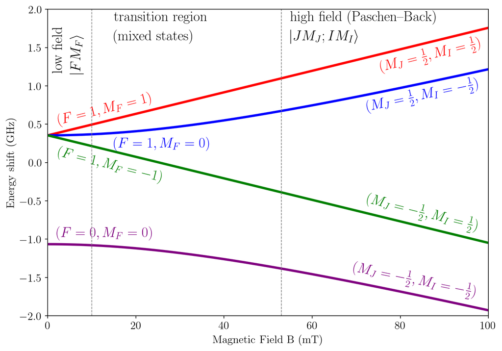

Figure 1: Hydrogen ground state energy shifts in a magnetic field.

```python
import numpy as np
import matplotlib.pyplot as plt

# Set the global font size
plt.rcParams['font.size'] = 14

# Enable LaTeX rendering
plt.rcParams['text.usetex'] = True

# Optionally, configure the font family to match your LaTeX document
plt.rcParams['font.family'] = 'serif'
plt.rcParams['font.serif'] = 'Computer Modern'

# Example LaTeX preambles can be set for more advanced customization
plt.rcParams['text.latex.preamble'] = r'\usepackage{amsmath} \usepackage{physics}'

# --- Physical Constants (in SI units) ---
h = 6.62607015e-34  # Planck's constant (J·s)
mu_B = 9.2740100783e-24  # Bohr magneton (J/T)
g_J = 2.00231930436256  # Electron g-factor
g_I_proton = 5.585694702  # Proton g-factor

# --- Hydrogen Ground State Parameters ---
delta_E_hz = 1420.405751768e6  # Hyperfine splitting frequency (Hz)
delta_E_joules = h * delta_E_hz  # Hyperfine splitting energy (Joules)
I = 0.5  # Nuclear spin for Hydrogen

# --- Magnetic Field Range (Tesla) ---
B_field = np.linspace(0, 0.2, 500)  # From 0 to 0.2 Tesla

# --- Breit-Rabi Parameter 'x' ---
# The parameter x is defined as: x = (g_J * mu_B - g_I * mu_N) * B / delta_E
# Often, the g_I*mu_N term is neglected as it's much smaller, but let's use the full expression
# x = (g_J * mu_B * B_field) / delta_E_joules
# A more common form of x uses the total magnetic moments to be more accurate
x = (g_J*mu_B + g_I_proton*mu_B/1836.15) * B_field / delta_E_joules

# --- Breit-Rabi Formula Calculation ---
# For I = 1/2 and S = 1/2, the states are F=1, F=0
# The formula is E = -delta_E / 4 +- delta_E/2 * sqrt(1 + 2*mF*x + x^2)
# The '+' is for F=1, the '-' is for F=0, but this is only for the mF=0 states.
# We must use the general formula from the beginning.
# The general Breit-Rabi formula is:
# E_mF = -(delta_E/2) * (1/(2I+1)) +- (delta_E/2)*sqrt(1+x^2 + 4mF*x) for I=1/2

# Let's use the full formula for the four energy levels
# F=1, m_F=+1 state:
E1_plus1 = +delta_E_joules/4 + (delta_E_joules/2)*x

# F=1, m_F=0 state:
E1_0 = -delta_E_joules/4 + (delta_E_joules/2)*np.sqrt(1 + x**2)

# F=0, m_F=0 state:
E0_0 = -delta_E_joules/4 - (delta_E_joules/2)*np.sqrt(1 + x**2)

# F=1, m_F=-1 state:
E1_minus1 = delta_E_joules/4 - (delta_E_joules/2)*x

# --- Plotting ---
plt.figure(figsize=(10, 7))

# Plot the energy levels, converting to GHz for the y-axis
plt.plot(B_field * 1000, E1_plus1 / h / 1e9, label=r'$F=1, m_F=+1$', color='red', linewidth=3)
plt.plot(B_field * 1000, E1_0 / h / 1e9, label=r'$F=1, m_F=0$', color='blue', linewidth=3)
plt.plot(B_field * 1000, E0_0 / h / 1e9, label=r'$F=0, m_F=0$', color='purple', linewidth=3)
plt.plot(B_field * 1000, E1_minus1 / h / 1e9, label=r'$F=1, m_F=-1$', color='green', linewidth=3)

plt.text(75, 1.2, r'$(M_J=\tfrac{1}{2},M_I=\tfrac{1}{2})$', fontsize=18, color='red', rotation=14)
plt.text(72, 0.68, r'$(M_J=\tfrac{1}{2},M_I=-\tfrac{1}{2})$', fontsize=18, color='blue', rotation=12)
plt.text(72, -0.88, r'$(M_J=-\tfrac{1}{2},M_I=\tfrac{1}{2})$', fontsize=18, color='green', rotation=-14)
plt.text(69, -1.74, r'$(M_J=-\tfrac{1}{2},M_I=-\tfrac{1}{2})$', fontsize=18, color='purple', rotation=-11.5)

plt.text(2, 0.5, r'$(F=1,M_F=1)$', fontsize=18, color='red', rotation=14)
plt.text(15, 0.2, r'$(F=1,M_F=0)$', fontsize=18, color='blue', rotation=0)
plt.text(2, -0.25, r'$(F=1,M_F=-1)$', fontsize=18, color='green', rotation=-14)
plt.text(2, -0.97, r'$(F=0,M_F=0)$', fontsize=18, color='purple', rotation=0)

plt.axvline(x=10 , color='gray', linestyle='--', linewidth=0.8,
            label=r'low field region')
plt.axvline(x=53 , color='gray', linestyle='--', linewidth=0.8,
            label=r'high field region')

plt.text(1, 1.2, r'low field', fontsize=18, rotation=90)
plt.text(5, 1.2, r'$\ket{F M_F}$', fontsize=18, rotation=90)

plt.text(15, 1.85, r'transition region', fontsize=18)
plt.text(15, 1.6, r'(mixed states)', fontsize=18)



plt.text(55, 1.85, r'high field (Paschen--Back)', fontsize=18)
plt.text(55, 1.6, r'$\ket{J M_J; I M_I}$', fontsize=18)



plt.xlabel('Magnetic Field B (mT)')
plt.ylabel('Energy shift (GHz)')
plt.grid(False)
#plt.legend()
plt.xlim(0, 100.0)
plt.ylim(-2.0, 2.0)
plt.show()
```

(For completeness: the full Breit–Rabi formula and its derivation are standard and can be found in many textbooks — see the note below for a compact statement and derivation sketch.)

**NoteThe Breit–Rabi formula (reference and sketch)**

The Breit–Rabi formula gives closed expressions for the energy levels of an atom with $J=\tfrac12$ and arbitrary nuclear spin $I$ in an external magnetic field. For the special case $I=\tfrac12$ (hydrogen ground state) the formula simplifies considerably and yields the usual two linear Zeeman branches ($m_F=\pm1$) and two levels that mix and show the characteristic avoided-crossing behaviour for $m_F=0$.

Derivation sketch: 1. Write the Hamiltonian in the $\{|m_J,m_I\rangle\}$ product basis. 2. Use that $m_F=m_J+m_I$ is conserved, which decomposes the problem into $2\times2$ blocks. 3. Diagonalize each $2\times2$ block to get the analytic expressions.

For an authoritative source and compact formula see: C. Cohen-Tannoudji, B. Diu, and F. Laloë, *Quantum Mechanics* (Volume II) or the review by Steck (Rubidium data) where the Breit–Rabi formula is written out explicitly and applied to alkali ground states.

## 3.2 Order-of-magnitude numbers (useful estimates)

- Hyperfine splitting of hydrogen ground state (21-cm line):
  $$\nu_{\rm hfs} \approx 1420.405751768\ \mathrm{MHz},\qquad
  \Delta E_{\rm hfs}=h\nu_{\rm hfs}\approx 5.87\times10^{-6}\ \mathrm{eV}.$$
- Convert frequency to effective field:
  $$B_{\rm crossover}\approx \frac{\nu_{\rm hfs}}{\mu_B/h}
  \approx \frac{1.4204\ \mathrm{GHz}}{13.996245\ \mathrm{GHz/T}}
  \approx 0.1015\ \mathrm{T}.$$

  Thus around $\sim 0.1\ \mathrm{T}$ the Zeeman splitting becomes comparable to the zero-field hyperfine splitting for hydrogen.
- At $B=1\ \mathrm{T}$ the single-electron Zeeman frequency (in energy units)
  $$\Delta E_{\rm Z} = \mu_B B \approx 5.79\times10^{-5}\ \mathrm{eV}
  \quad\Longleftrightarrow\quad \frac{\Delta E_{\rm Z}}{h}\approx 13.996\ \mathrm{GHz}.$$

These numbers help decide which interactions dominate in a given laboratory situation.

### Typical experimental magnitudes

- Weak laboratory fields ($B\lesssim 1\ \mathrm{mT}$): Zeeman shifts are tiny; hyperfine structure typically dominates.
- Modest fields ($B\sim 0.01\!-\!0.2\ \mathrm{T}$): interesting interplay — use the Breit–Rabi description.
- Strong fields ($B\gtrsim 1\ \mathrm{T}$): Zeeman splitting dominates; $M_J,M_I$ are the convenient labels.

# 4. Atoms in electric fields — quadratic Stark effect

The interaction of an atom with a static electric field $\vec{\mathcal E}$ is given by

$$\hat H_{\rm St} = -\hat{\vec d}\cdot\vec{\mathcal E},$$

where $\hat{\vec d} = -e\,\hat{\vec r}$ is the electric dipole operator of the electron.  
For simplicity we assume the field points along $z$:

$$\hat H_{\rm St} = e\,\mathcal E\,\hat z.$$

## 4.1 Perturbation theory setup

We apply time-independent perturbation theory in the basis of hydrogen eigenstates $|n,\ell,m\rangle$. The first- and second-order energy corrections are

$$\Delta E^{(1)}_{n\ell m} = \langle n\ell m| e\mathcal E z |n\ell m\rangle,$$

$$\Delta E^{(2)}_{n\ell m} = \sum_{n'\ell' m' \neq n\ell m}
\frac{|\langle n'\ell' m'| e\mathcal E z |n\ell m\rangle|^2}{E_{n\ell}-E_{n'\ell'}}.$$

## 4.2 Why the first order vanishes

For hydrogen eigenstates, the expectation value $\langle n\ell m| z |n\ell m\rangle$ vanishes.  
This can be seen in two ways:

- **Symmetry argument.** The $z$ operator is odd under inversion $(x,y,z)\mapsto (-x,-y,-z)$. Hydrogen eigenfunctions have definite parity $(-1)^\ell$. Thus the integrand in $\int \psi^*(r)\,z\,\psi(r)\,d^3r$ is odd, and the integral is zero.
- **Physical picture.** Stationary hydrogen states have no permanent dipole moment. The probability distribution is symmetric around the nucleus, so the average $z$ coordinate vanishes.

Therefore, $\Delta E^{(1)}=0$ for all $|n,\ell,m\rangle$ eigenstates.

## 4.3 Second-order shift and dipole matrix elements

The leading Stark effect is therefore quadratic, arising from the second-order term. It depends on dipole matrix elements of the form $\langle n'\ell' m'| z |n\ell m\rangle$, which connect states of opposite parity ($\ell'=\ell\pm 1$). These terms encode the atom’s ability to be polarized by the field.

We will not evaluate these matrix elements here — they become central in the discussion of light–matter interaction, where the dipole operator governs optical transitions.

### Worked example: $2s$–$2p$ mixing

The $2s$ state has $\ell=0$ (even parity). The operator $z$ connects it to $2p$ states ($\ell=1$), which have odd parity:

$$\langle 2p,m|\;z\;|2s\rangle \neq 0.$$

Thus the second-order Stark shift of the $2s$ level includes terms like

$$\Delta E^{(2)}_{2s} =
\sum_{m=-1}^{1}\frac{|\langle 2p,m|\,e\mathcal E z\,|2s\rangle|^2}{E_{2s}-E_{2p}}.$$

- The numerator is the squared dipole matrix element (strength of $2s\leftrightarrow 2p$ coupling).
- The denominator is the energy difference between $2s$ and $2p$ (which is zero in pure Schrödinger theory, but shifted by Lamb shift in reality).

This shows explicitly why the Stark effect is quadratic in $\mathcal E$:  
the energy correction involves $|\langle\cdot|z|\cdot\rangle|^2\mathcal E^2$.

## 4.4 Result for hydrogen ground state

For the hydrogen ground state ($1s$), the quadratic Stark shift can be summarized as

$$\Delta E = -\tfrac{1}{2}\,\alpha\,\mathcal E^2,$$

where $\alpha$ is the static electric polarizability. For $1s$ hydrogen:

$$\alpha(1s) \approx 4.5\,a_0^3,$$

with $a_0$ the Bohr radius. In SI units, $\alpha$ may be converted to J/(V/m)$^2$.

## 4.5 Order of magnitude estimate

For a field of $\mathcal E=10^6\ \mathrm{V/m}$ (a large laboratory field) the shift is tiny:

$$\Delta E \sim -\tfrac{1}{2}\,(4.5\,a_0^3)\,(10^6\ \mathrm{V/m})^2,$$

which is negligible compared with hyperfine and Zeeman splittings under similar conditions.

**NoteQuick remark on polarizability and units**

The quoted polarizability $\alpha(1s)\approx 4.5\,a_0^3$ is in atomic units. To convert to SI (J m$^2$/V$^2$ or C m$^2$/V), apply the standard atomic-unit conversion factors. For conceptual discussions, the $a_0^3$ form is typically sufficient.